# Seshat

Achille-Laurent

15/04/2020

## 1. Les données

- Seshat global history databank
- Variables complexité sociale etc
- Renormalisée, populations en log
- Mis sous python pour avoir un meileur index
- Inspiré de l’article

## 3. Analyse de la base normalisée

- base date compter comme différente

```r
dfn <- read.csv('axial_index.csv',sep=',')
# Mettre l'Index en index et retirer SPC1
data <- subset(dfn, select=-c(Index,Time,NGA,PolID))
rownames(data) <- dfn$Index
attach(data)
head(data)
```

```
##                       PolPop  PolTerr   CapPop      levels government infrastr
## Konya Plain (-9600) 3.293724 4.138263 1.442118 -0.05581711          0        0
## Konya Plain (-9500) 3.293724 4.138263 1.442118 -0.05581711          0        0
## Konya Plain (-9400) 3.293724 4.138263 1.442118 -0.05581711          0        0
## Konya Plain (-9300) 3.293724 4.138263 1.442118 -0.05581711          0        0
## Konya Plain (-9200) 3.293724 4.138263 1.442118 -0.05581711          0        0
## Konya Plain (-9100) 3.293724 4.138263 1.442118 -0.05581711          0        0
##                     writing texts money
## Konya Plain (-9600)       0     0     0
## Konya Plain (-9500)       0     0     0
## Konya Plain (-9400)       0     0     0
## Konya Plain (-9300)       0     0     0
## Konya Plain (-9200)       0     0     0
## Konya Plain (-9100)       0     0     0
```

### 3.1. Vue d’ensemble

- boxplot

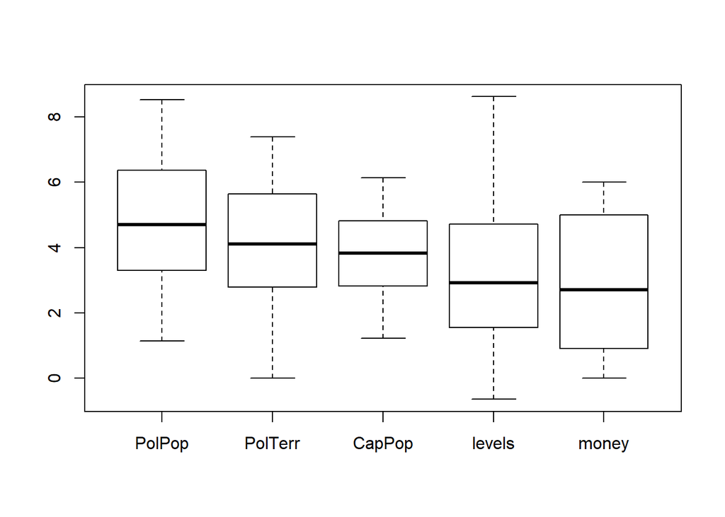

```r
# Séparer les 2 plots qui sont d'échelle différente
boxplot(subset(data,select = c(PolPop,PolTerr,CapPop,levels,money)))
```

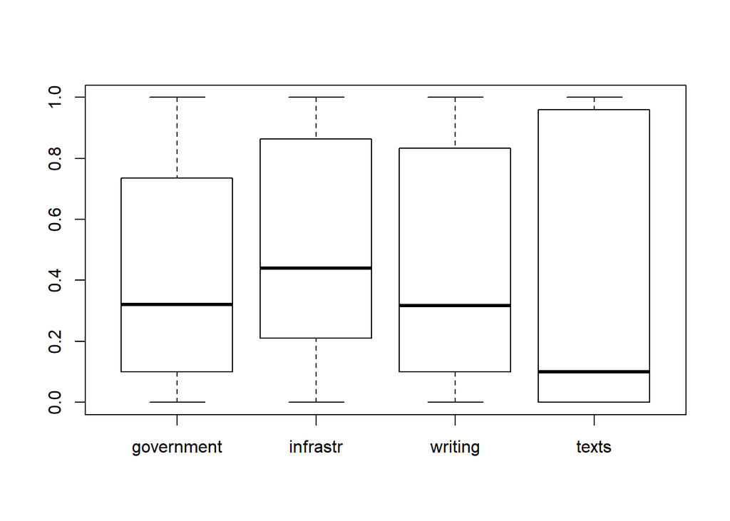

```r
boxplot(subset(data,select = c(government,infrastr,writing,texts)))
```

### 3.2. ACP

- (2D, Prop Variance)

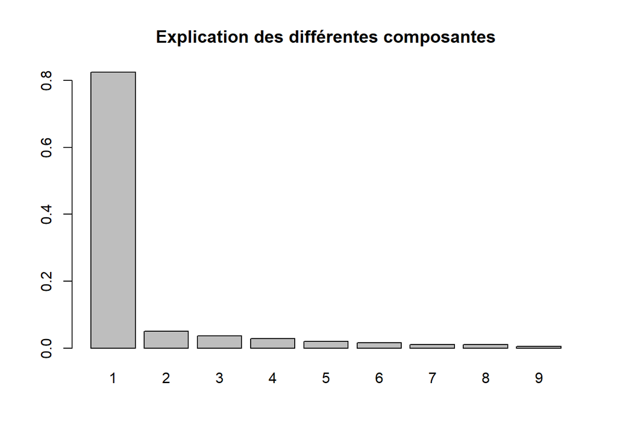

```r
X= scale(data, center=T, scale=T)

S = cov(X)
acp = eigen(S)
lambda = acp$values
vecteurs_propres = acp$vectors
Inertie = sum(diag(S))
part.inertie = lambda/sum(lambda)
barplot(lambda/sum(lambda),names.arg = 1:length(lambda))
title(main="Explication des différentes composantes")
```

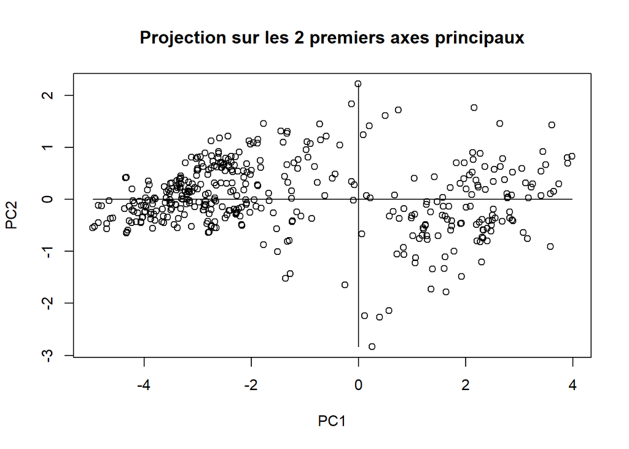

```r
# Les composantes principales :
C = X %*% vecteurs_propres
# colnames(C) =   paste("comp", 1:4)
plot(C[,1:2],type="p",xlab='PC1',ylab='PC2')
# text(C[,1:2])
title(main="Projection sur les 2 premiers axes principaux")
lines(c(min(C[,1]),max(C[,1])),c(0,0))
lines(c(0,0),c(min(C[,2]),max(C[,2])))
```

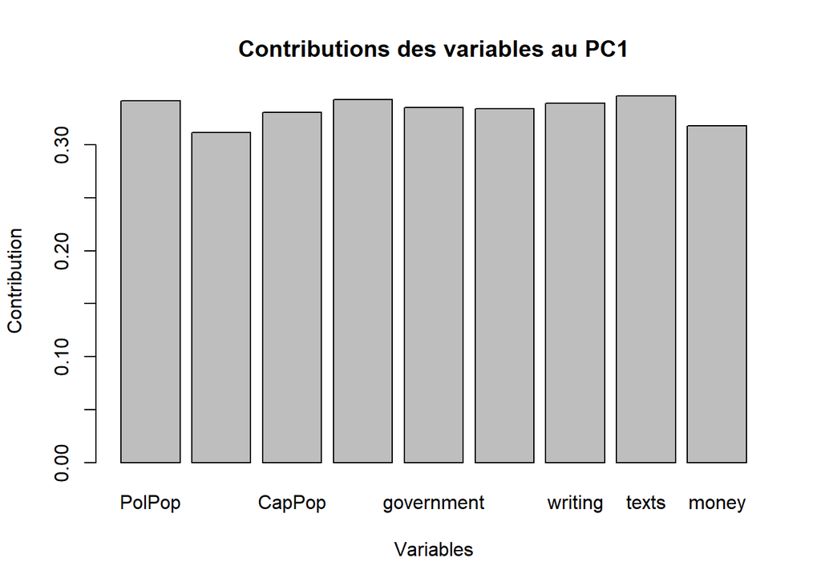

```r
barplot(-vecteurs_propres[,1],ylab = 'Contribution',xlab = 'Variables',names.arg = names(data),axes = TRUE)
title(main="Contributions des variables au PC1")
```

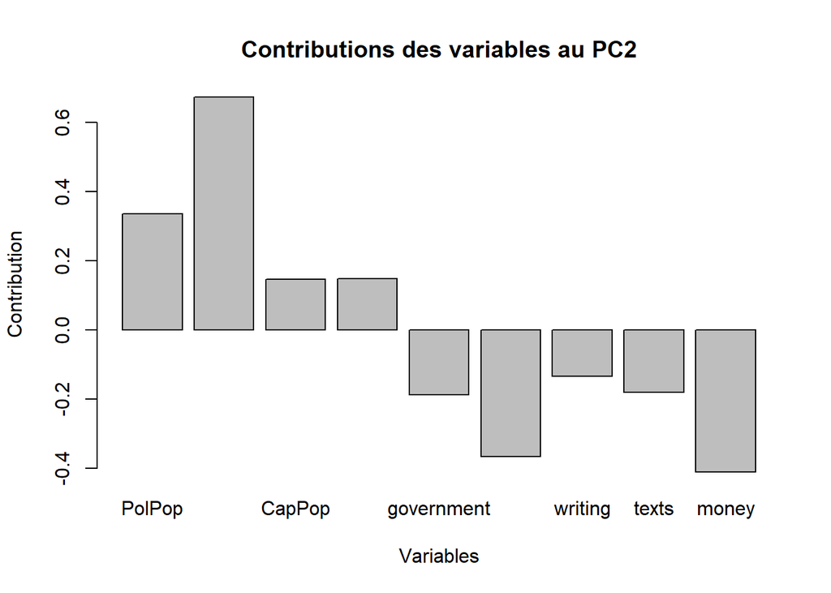

```r
barplot(-vecteurs_propres[,2],ylab = 'Contribution',xlab = 'Variables',names.arg = names(data),axes = TRUE)
title(main="Contributions des variables au PC2")
```

Remarquer que : * La premiere composante explique tout : interpréter * On peut remarquer deux clusters sur l’ACP * Toutes les variables contribuent de la même façon au PC1, interpréter * Pour le pc2 on observe des nuances d’ordre similaire, voir cercle

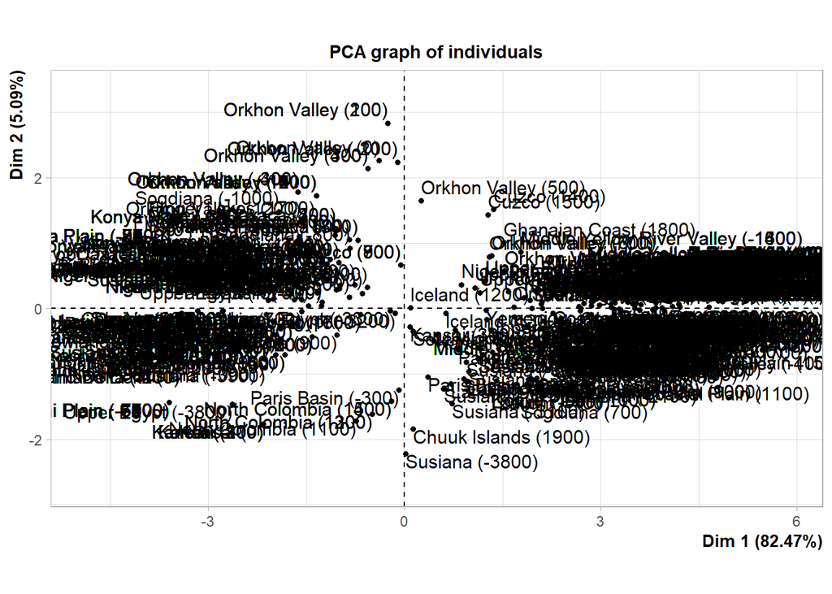

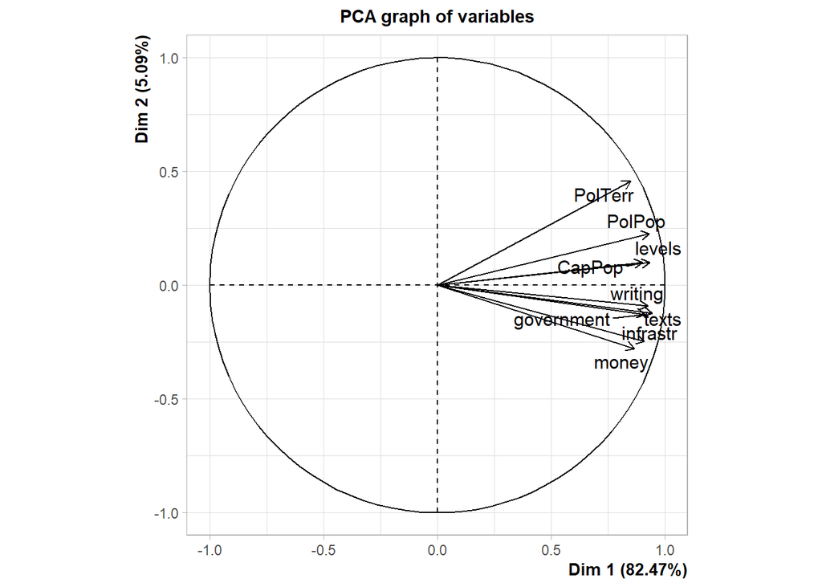

```r
library(FactoMineR)
pca <- PCA(data, scale.unit = TRUE, ncp = 11, graph = TRUE)
```

### 3.3 k-means et CAH

On a vu sur l’ACP qu’on pouvait distinguer environ deux groupes. On essaie des k-means :

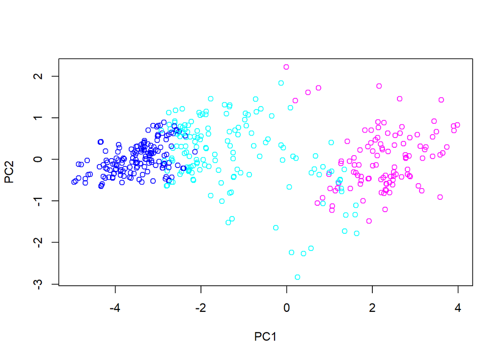

```r
kmeans.result = kmeans(data,3)
plot(C[,1:2],type="p",xlab='PC1',ylab='PC2',col = kmeans.result$cluster+3)
```

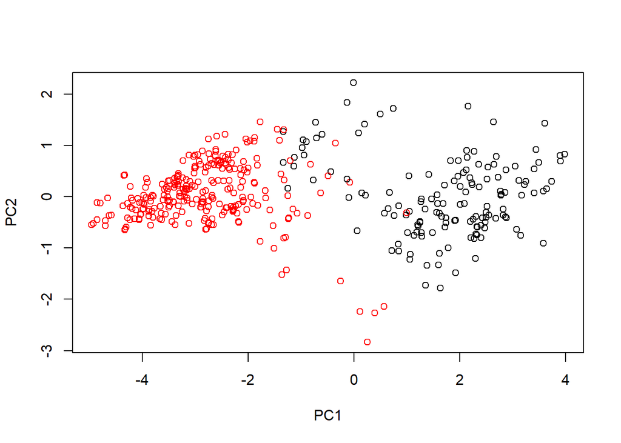

```r
kmeans.result = kmeans(data,2)
plot(C[,1:2],type="p",xlab='PC1',ylab='PC2',col =kmeans.result$cluster)
```

```r
kmeans.result$cluster
```

[output not shown]

[output cut: 809 more lines]

[output not shown]

Pour k = 3, on a un groupe qui contient les points dispersés du milieu. Pour savoir quelle classification est la plus pertinente, essayons un CAH :

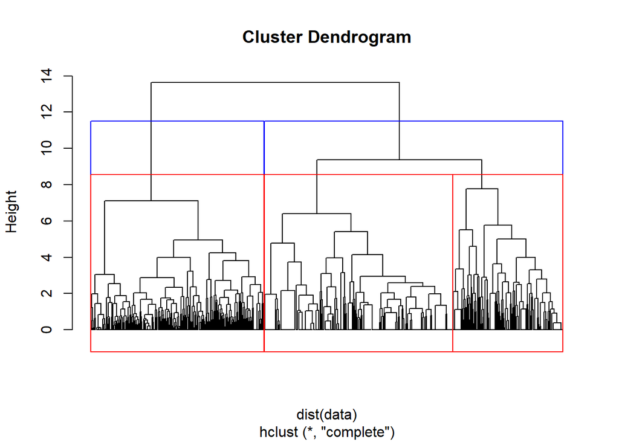

```r
hc <- hclust(dist(data))
plot(hc,hang=-1,labels = FALSE)
rect.hclust(hc,k=2,border = 4)
rect.hclust(hc,k=3)
```

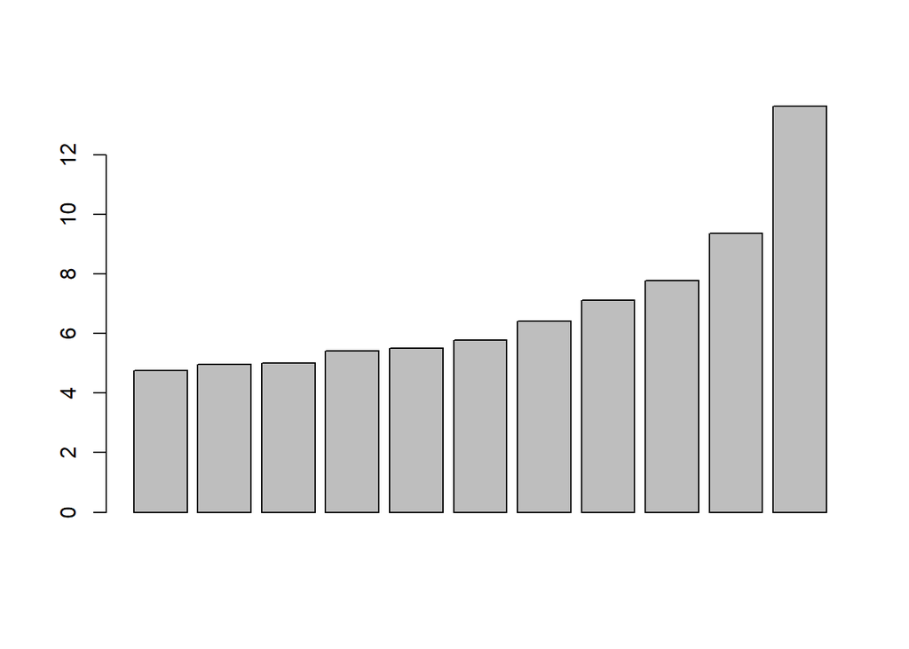

```r
barplot(hc$height[(length(hc$height)-10):(length(hc$height))])
```

On ne peut pas vraiment savoir si c’est deux ou 3 classes qu’on peut garder … Essayons avec pam

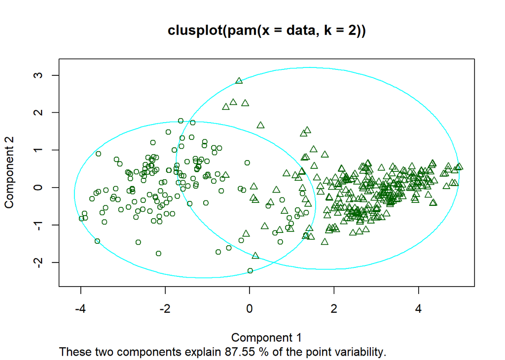

[figure not shown]

```r
library(cluster)
pam.result <- pam(data,2)
plot(pam.result)
```

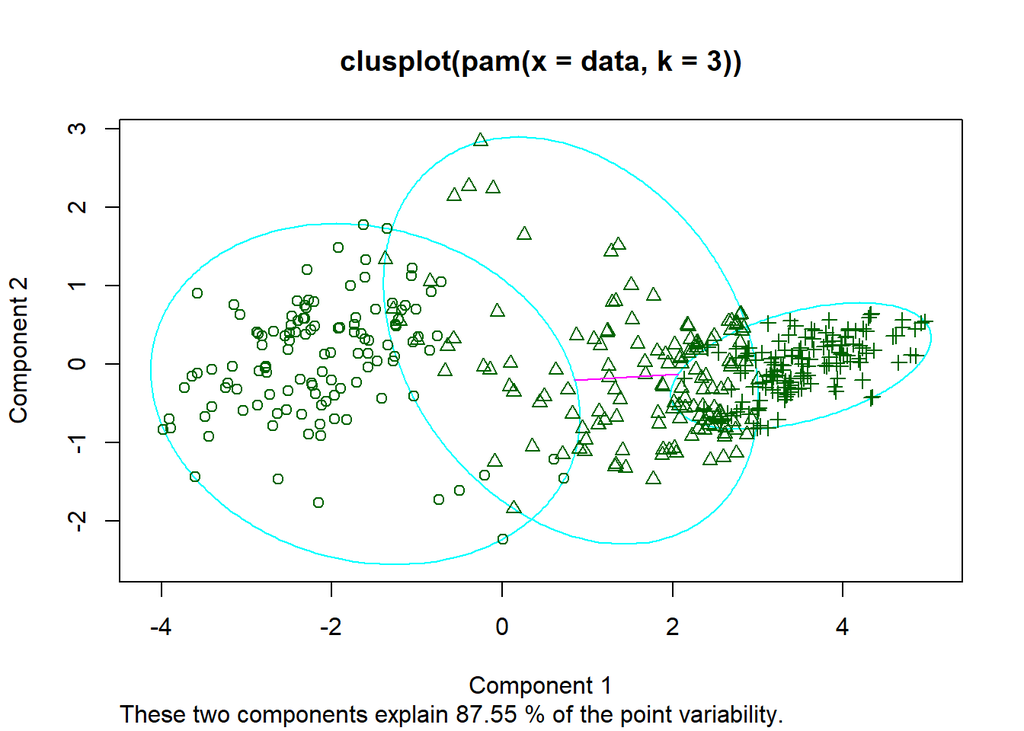

[figure not shown]

```r
pam.result <- pam(data,3)
plot(pam.result)
```

Je ne sais pas trop ce que tout cela signifie. Peut être du côté de la fonction FAMD ?

Une fois les groupes réunis, il serait intéressant de comprendre ce qui les distingue, les deux dimensions n’y suffisent pas entièrement :

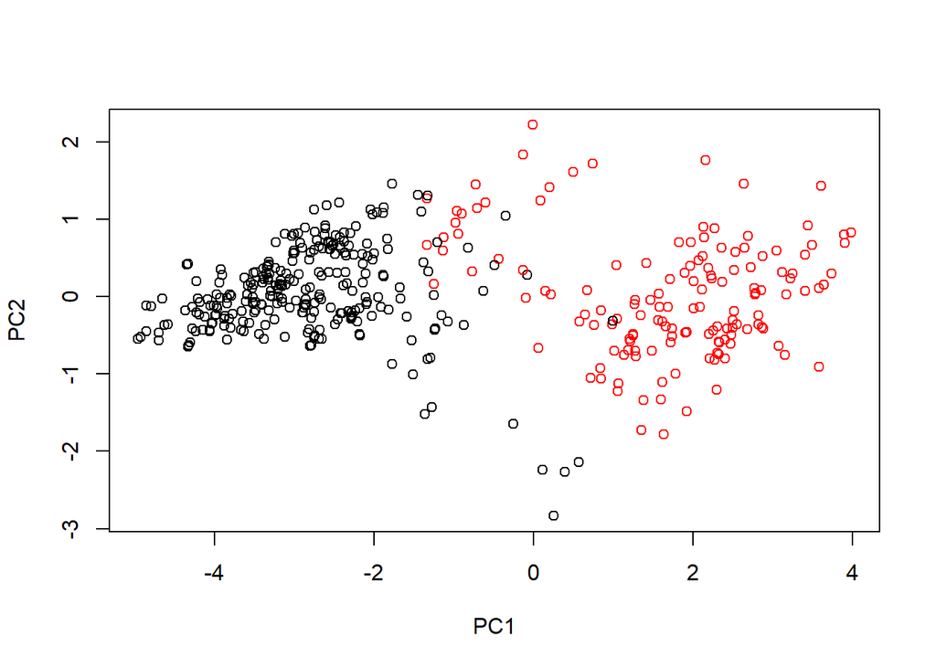

```r
k = 2
kmeans.result = kmeans(data,k)
plot(C[,1:2],type="p",xlab='PC1',ylab='PC2',col = kmeans.result$cluster)
```

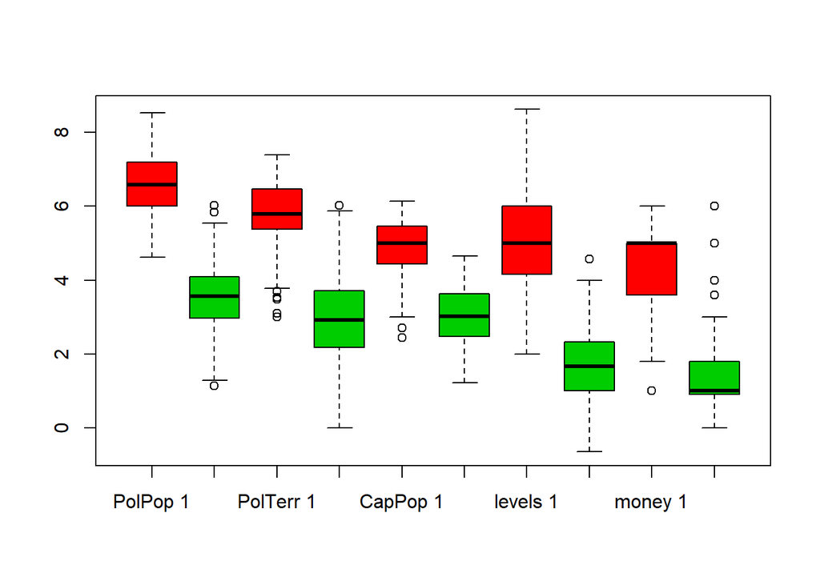

```r
for(i in 1:k)

data.petit = subset(data,select = c(government,infrastr,writing,texts))
data.grand = subset(data,select = c(PolPop,PolTerr,CapPop,levels,money))
data.grand.all = list()

for(nom in names(data.grand))
{
  for(i in 1:k)
  {
      data.grand.all[[paste(nom,i)]] <- data.grand[kmeans.result$cluster==i,nom]
  }
}
boxplot(data.grand.all,col = rep(c(2:(k+1)),length(data.grand)))
```

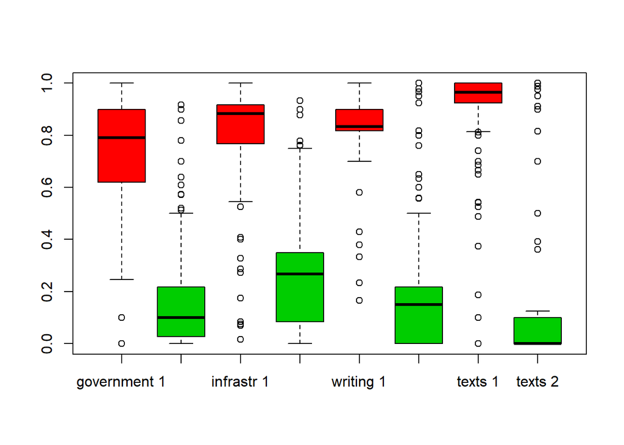

```r
data.petit.all = list()

for(nom in names(data.petit))
{
  for(i in 1:k)
  {
      data.petit.all[[paste(nom,i)]] <- data.petit[kmeans.result$cluster==i,nom]
  }
}
boxplot(data.petit.all,col = rep(c(2:(k+1)),length(data.petit)))
```

```r
# data.petit.all <- list(data.petit.1$government,data.petit.2$government))
# head(data.petit.all)
```

### 3.4 K-fold

- cross validation

### 3.5 Autres

- tests,lm, beackward forward,
- temps (k means sur évolution PC1)

## 2. Analyse aveec arbres moraux

On utilise les nouveaux groupes ppur tenter de classifier avec des forêts sur les variables morales On commence par importer la base morale

```r
# detach(data)
dfm <- read.csv('morale_index_inaxe.csv',sep=',')
# Mettre l'Index en index et retirer SPC1
datam <- subset(dfm, select=-c(Index,Time,NGA,sum))
rownames(datam) <- dfm$Index
attach(datam)
head(datam)
```

```
##                     X1._Moralistic_punishment X2._Moralizing_norms
## Upper Egypt (-4400)                         0                    0
## Upper Egypt (-4300)                         0                    0
## Upper Egypt (-4200)                         0                    0
## Upper Egypt (-4100)                         0                    0
## Upper Egypt (-4000)                         0                    0
## Upper Egypt (-3900)                         0                    0
##                     X3._Promotion_of_prosociality
## Upper Egypt (-4400)                             0
## Upper Egypt (-4300)                             0
## Upper Egypt (-4200)                             0
## Upper Egypt (-4100)                             0
## Upper Egypt (-4000)                             0
## Upper Egypt (-3900)                             0
##                     X4._Omniscient_supernatural_beings X5._Rulers_not_gods
## Upper Egypt (-4400)                                  0                   0
## Upper Egypt (-4300)                                  0                   0
## Upper Egypt (-4200)                                  0                   0
## Upper Egypt (-4100)                                  0                   0
## Upper Egypt (-4000)                                  0                   0
## Upper Egypt (-3900)                                  0                   0
##                     X6._Equating_elites_and_commoners
## Upper Egypt (-4400)                                 0
## Upper Egypt (-4300)                                 0
## Upper Egypt (-4200)                                 0
## Upper Egypt (-4100)                                 0
## Upper Egypt (-4000)                                 0
## Upper Egypt (-3900)                                 0
##                     X7._Equating_rulers_and_commoners X8._Formal_legal_code
## Upper Egypt (-4400)                                 0                     0
## Upper Egypt (-4300)                                 0                     0
## Upper Egypt (-4200)                                 0                     0
## Upper Egypt (-4100)                                 0                     0
## Upper Egypt (-4000)                                 0                     0
## Upper Egypt (-3900)                                 0                     0
##                     X9._General_applicability_of_law
## Upper Egypt (-4400)                                0
## Upper Egypt (-4300)                                0
## Upper Egypt (-4200)                                0
## Upper Egypt (-4100)                                0
## Upper Egypt (-4000)                                0
## Upper Egypt (-3900)                                0
##                     X10._Constraint_on_executive X11._Full.time_bureaucrats
## Upper Egypt (-4400)                            0                          0
## Upper Egypt (-4300)                            0                          0
## Upper Egypt (-4200)                            0                          0
## Upper Egypt (-4100)                            0                          0
## Upper Egypt (-4000)                            0                          0
## Upper Egypt (-3900)                            0                          0
##                     X12._Impeachment
## Upper Egypt (-4400)                0
## Upper Egypt (-4300)                0
## Upper Egypt (-4200)                0
## Upper Egypt (-4100)                0
## Upper Egypt (-4000)                0
## Upper Egypt (-3900)                0
```

On associe ensuite à chaque individu dans la base morale son cluster (1 ou 2) correspondant

```r
rreess <- kmeans.result$cluster
datam$cluster <- (rreess[(dfn$Index)%in%(dfm$Index)] ==1)*1
head(datam)
```

```
##                     X1._Moralistic_punishment X2._Moralizing_norms
## Upper Egypt (-4400)                         0                    0
## Upper Egypt (-4300)                         0                    0
## Upper Egypt (-4200)                         0                    0
## Upper Egypt (-4100)                         0                    0
## Upper Egypt (-4000)                         0                    0
## Upper Egypt (-3900)                         0                    0
##                     X3._Promotion_of_prosociality
## Upper Egypt (-4400)                             0
## Upper Egypt (-4300)                             0
## Upper Egypt (-4200)                             0
## Upper Egypt (-4100)                             0
## Upper Egypt (-4000)                             0
## Upper Egypt (-3900)                             0
##                     X4._Omniscient_supernatural_beings X5._Rulers_not_gods
## Upper Egypt (-4400)                                  0                   0
## Upper Egypt (-4300)                                  0                   0
## Upper Egypt (-4200)                                  0                   0
## Upper Egypt (-4100)                                  0                   0
## Upper Egypt (-4000)                                  0                   0
## Upper Egypt (-3900)                                  0                   0
##                     X6._Equating_elites_and_commoners
## Upper Egypt (-4400)                                 0
## Upper Egypt (-4300)                                 0
## Upper Egypt (-4200)                                 0
## Upper Egypt (-4100)                                 0
## Upper Egypt (-4000)                                 0
## Upper Egypt (-3900)                                 0
##                     X7._Equating_rulers_and_commoners X8._Formal_legal_code
## Upper Egypt (-4400)                                 0                     0
## Upper Egypt (-4300)                                 0                     0
## Upper Egypt (-4200)                                 0                     0
## Upper Egypt (-4100)                                 0                     0
## Upper Egypt (-4000)                                 0                     0
## Upper Egypt (-3900)                                 0                     0
##                     X9._General_applicability_of_law
## Upper Egypt (-4400)                                0
## Upper Egypt (-4300)                                0
## Upper Egypt (-4200)                                0
## Upper Egypt (-4100)                                0
## Upper Egypt (-4000)                                0
## Upper Egypt (-3900)                                0
##                     X10._Constraint_on_executive X11._Full.time_bureaucrats
## Upper Egypt (-4400)                            0                          0
## Upper Egypt (-4300)                            0                          0
## Upper Egypt (-4200)                            0                          0
## Upper Egypt (-4100)                            0                          0
## Upper Egypt (-4000)                            0                          0
## Upper Egypt (-3900)                            0                          0
##                     X12._Impeachment cluster
## Upper Egypt (-4400)                0       0
## Upper Egypt (-4300)                0       0
## Upper Egypt (-4200)                0       0
## Upper Egypt (-4100)                0       0
## Upper Egypt (-4000)                0       0
## Upper Egypt (-3900)                0       0
```

Onpeut ensuite faire un arbre

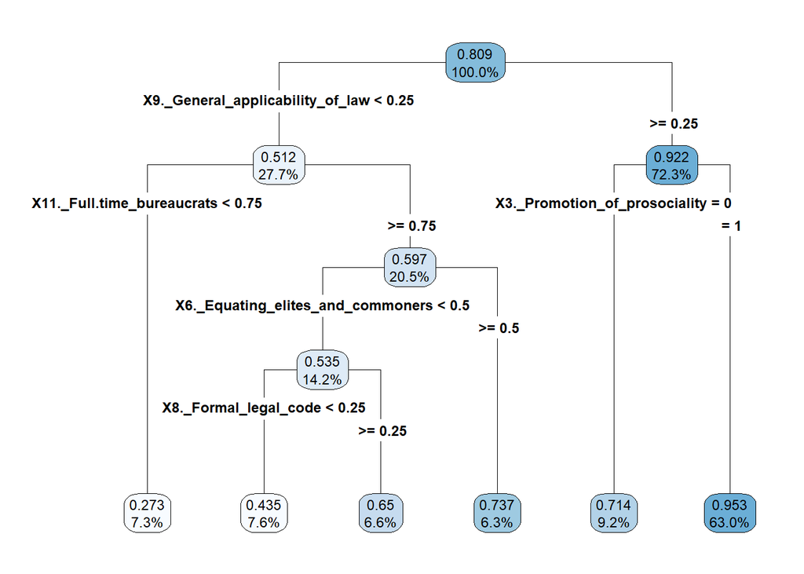

```r
library(rpart)
arbre=rpart(datam$cluster~.,datam)
# summary(arbre)
# print(arbre)
library(rpart.plot)
rpart.plot(arbre, type=4, digits=3)
```

```r
# library(randomForest)
# RF <- randomForest(datam$cluster~.,datam)
# pred_RF <- predict(fit_RF,newdata=NewDATA, type="prob")
# pred_RF
```

Ou plutôt de la régression logistique

```r
res <- glm(cluster~.,family=binomial,data=datam)
summary(res)
```

```
##
## Call:
## glm(formula = cluster ~ ., family = binomial, data = datam)
##
## Deviance Residuals:
##     Min       1Q   Median       3Q      Max
## -3.4475   0.0581   0.1950   0.5118   1.6117
##
## Coefficients:
##                                    Estimate Std. Error z value Pr(>|z|)
## (Intercept)                         -0.9801     0.4426  -2.214 0.026803 *
## X1._Moralistic_punishment           -2.2834     0.8484  -2.691 0.007117 **
## X2._Moralizing_norms                -0.5112     0.6930  -0.738 0.460695
## X3._Promotion_of_prosociality        1.4368     0.5674   2.532 0.011331 *
## X4._Omniscient_supernatural_beings   2.4379     1.2431   1.961 0.049853 *
## X5._Rulers_not_gods                 -0.4511     0.6884  -0.655 0.512308
## X6._Equating_elites_and_commoners   -0.2055     0.8437  -0.244 0.807553
## X7._Equating_rulers_and_commoners    2.1845     0.9698   2.253 0.024285 *
## X8._Formal_legal_code                0.9356     0.6282   1.489 0.136373
## X9._General_applicability_of_law     2.4217     0.7191   3.368 0.000758 ***
## X10._Constraint_on_executive        -1.5355     0.7283  -2.108 0.035000 *
## X11._Full.time_bureaucrats           0.6503     0.5234   1.243 0.214009
## X12._Impeachment                     1.0425     0.8235   1.266 0.205531
## ---
## Signif. codes:  0 '***' 0.001 '**' 0.01 '*' 0.05 '.' 0.1 ' ' 1
##
## (Dispersion parameter for binomial family taken to be 1)
##
##     Null deviance: 295.89  on 302  degrees of freedom
## Residual deviance: 190.92  on 290  degrees of freedom
## AIC: 216.92
##
## Number of Fisher Scoring iterations: 7
```

```r
exp(res$coefficients)
```

```
##                        (Intercept)          X1._Moralistic_punishment
##                          0.3752810                          0.1019414
##               X2._Moralizing_norms      X3._Promotion_of_prosociality
##                          0.5997592                          4.2074037
## X4._Omniscient_supernatural_beings                X5._Rulers_not_gods
##                         11.4491608                          0.6369282
##  X6._Equating_elites_and_commoners  X7._Equating_rulers_and_commoners
##                          0.8142326                          8.8862247
##              X8._Formal_legal_code   X9._General_applicability_of_law
##                          2.5488605                         11.2649718
##       X10._Constraint_on_executive         X11._Full.time_bureaucrats
##                          0.2153397                          1.9161609
##                   X12._Impeachment
##                          2.8362184
```

```r
res0 <- glm(cluster~1,family=binomial,data=datam)
anova(res0,res,test="Chisq")
```

```
## Analysis of Deviance Table
##
## Model 1: cluster ~ 1
## Model 2: cluster ~ X1._Moralistic_punishment + X2._Moralizing_norms +
##     X3._Promotion_of_prosociality + X4._Omniscient_supernatural_beings +
##     X5._Rulers_not_gods + X6._Equating_elites_and_commoners +
##     X7._Equating_rulers_and_commoners + X8._Formal_legal_code +
##     X9._General_applicability_of_law + X10._Constraint_on_executive +
##     X11._Full.time_bureaucrats + X12._Impeachment
##   Resid. Df Resid. Dev Df Deviance  Pr(>Chi)
## 1       302     295.89
## 2       290     190.92 12   104.97 < 2.2e-16 ***
## ---
## Signif. codes:  0 '***' 0.001 '**' 0.01 '*' 0.05 '.' 0.1 ' ' 1
```

```r
library(MASS)
res_AIC <- step(res)  #backward par defaut
```

```
## Start:  AIC=216.92
## cluster ~ X1._Moralistic_punishment + X2._Moralizing_norms +
##     X3._Promotion_of_prosociality + X4._Omniscient_supernatural_beings +
##     X5._Rulers_not_gods + X6._Equating_elites_and_commoners +
##     X7._Equating_rulers_and_commoners + X8._Formal_legal_code +
##     X9._General_applicability_of_law + X10._Constraint_on_executive +
##     X11._Full.time_bureaucrats + X12._Impeachment
##
##                                      Df Deviance    AIC
## - X6._Equating_elites_and_commoners   1   190.98 214.98
## - X5._Rulers_not_gods                 1   191.35 215.35
## - X2._Moralizing_norms                1   191.48 215.48
## - X11._Full.time_bureaucrats          1   192.48 216.48
## - X12._Impeachment                    1   192.60 216.60
## <none>                                    190.92 216.92
## - X8._Formal_legal_code               1   193.14 217.14
## - X10._Constraint_on_executive        1   195.71 219.71
## - X7._Equating_rulers_and_commoners   1   196.23 220.23
## - X4._Omniscient_supernatural_beings  1   196.53 220.53
## - X3._Promotion_of_prosociality       1   197.63 221.63
## - X1._Moralistic_punishment           1   197.65 221.65
## - X9._General_applicability_of_law    1   203.75 227.75
##
## Step:  AIC=214.98
## cluster ~ X1._Moralistic_punishment + X2._Moralizing_norms +
##     X3._Promotion_of_prosociality + X4._Omniscient_supernatural_beings +
##     X5._Rulers_not_gods + X7._Equating_rulers_and_commoners +
##     X8._Formal_legal_code + X9._General_applicability_of_law +
##     X10._Constraint_on_executive + X11._Full.time_bureaucrats +
##     X12._Impeachment
##
##                                      Df Deviance    AIC
## - X5._Rulers_not_gods                 1   191.36 213.36
## - X2._Moralizing_norms                1   191.75 213.75
## - X11._Full.time_bureaucrats          1   192.50 214.50
## <none>                                    190.98 214.98
## - X12._Impeachment                    1   192.99 214.99
## - X8._Formal_legal_code               1   193.20 215.20
## - X4._Omniscient_supernatural_beings  1   196.54 218.54
## - X10._Constraint_on_executive        1   196.66 218.66
```

[output cut: 45 more lines]

```
## cluster ~ X1._Moralistic_punishment + X3._Promotion_of_prosociality +
##     X4._Omniscient_supernatural_beings + X7._Equating_rulers_and_commoners +
##     X9._General_applicability_of_law + X10._Constraint_on_executive +
##     X11._Full.time_bureaucrats + X12._Impeachment
##
##                                      Df Deviance    AIC
## <none>                                    193.72 211.72
## - X12._Impeachment                    1   196.24 212.24
## - X11._Full.time_bureaucrats          1   196.39 212.39
## - X1._Moralistic_punishment           1   200.10 216.10
## - X10._Constraint_on_executive        1   200.20 216.20
## - X4._Omniscient_supernatural_beings  1   200.43 216.43
## - X7._Equating_rulers_and_commoners   1   200.51 216.51
## - X3._Promotion_of_prosociality       1   203.89 219.89
## - X9._General_applicability_of_law    1   210.74 226.74
```

```r
summary(res_AIC)
```

```
##
## Call:
## glm(formula = cluster ~ X1._Moralistic_punishment + X3._Promotion_of_prosociality +
##     X4._Omniscient_supernatural_beings + X7._Equating_rulers_and_commoners +
##     X9._General_applicability_of_law + X10._Constraint_on_executive +
##     X11._Full.time_bureaucrats + X12._Impeachment, family = binomial,
##     data = datam)
##
## Deviance Residuals:
##     Min       1Q   Median       3Q      Max
## -3.5239   0.0701   0.2327   0.5169   1.6513
##
## Coefficients:
##                                    Estimate Std. Error z value Pr(>|z|)
## (Intercept)                         -1.0680     0.4301  -2.483 0.013030 *
## X1._Moralistic_punishment           -2.2065     0.8322  -2.651 0.008014 **
## X3._Promotion_of_prosociality        1.4964     0.4820   3.104 0.001907 **
## X4._Omniscient_supernatural_beings   2.6113     1.2348   2.115 0.034455 *
## X7._Equating_rulers_and_commoners    1.4504     0.5903   2.457 0.014006 *
## X9._General_applicability_of_law     2.3946     0.6167   3.883 0.000103 ***
## X10._Constraint_on_executive        -1.6501     0.6786  -2.432 0.015032 *
## X11._Full.time_bureaucrats           0.7727     0.4756   1.625 0.104248
## X12._Impeachment                     1.1235     0.7434   1.511 0.130725
## ---
## Signif. codes:  0 '***' 0.001 '**' 0.01 '*' 0.05 '.' 0.1 ' ' 1
##
## (Dispersion parameter for binomial family taken to be 1)
##
##     Null deviance: 295.89  on 302  degrees of freedom
## Residual deviance: 193.72  on 294  degrees of freedom
## AIC: 211.72
##
## Number of Fisher Scoring iterations: 7
```

```r
anova(res_AIC,res,test="Chisq")
```

```
## Analysis of Deviance Table
##
## Model 1: cluster ~ X1._Moralistic_punishment + X3._Promotion_of_prosociality +
##     X4._Omniscient_supernatural_beings + X7._Equating_rulers_and_commoners +
##     X9._General_applicability_of_law + X10._Constraint_on_executive +
##     X11._Full.time_bureaucrats + X12._Impeachment
## Model 2: cluster ~ X1._Moralistic_punishment + X2._Moralizing_norms +
##     X3._Promotion_of_prosociality + X4._Omniscient_supernatural_beings +
##     X5._Rulers_not_gods + X6._Equating_elites_and_commoners +
##     X7._Equating_rulers_and_commoners + X8._Formal_legal_code +
##     X9._General_applicability_of_law + X10._Constraint_on_executive +
##     X11._Full.time_bureaucrats + X12._Impeachment
##   Resid. Df Resid. Dev Df Deviance Pr(>Chi)
## 1       294     193.72
## 2       290     190.92  4    2.795   0.5927
```

```r
NewDATA=data.frame(dfm)
pred=predict(res_AIC, newdata=NewDATA, type="response")  #donne proba d'atre dans classe 1
# table(pred,rreess)
```

```r
# library(carData)
# vif(res_AIC)
```

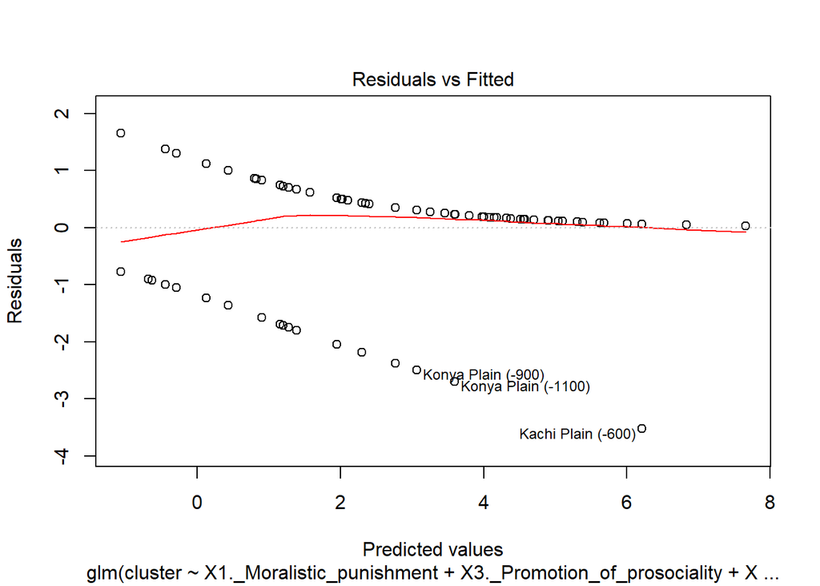

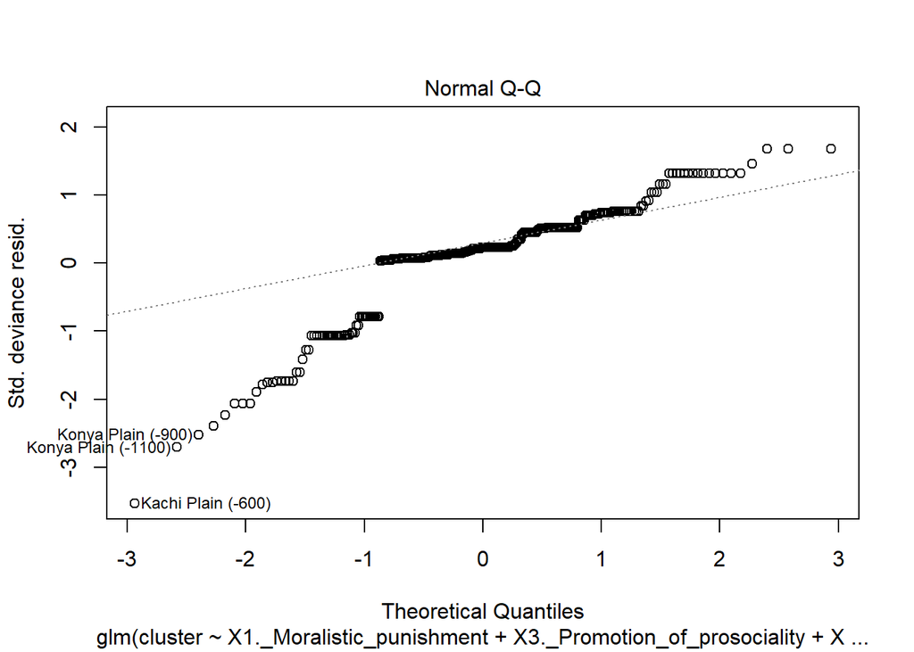

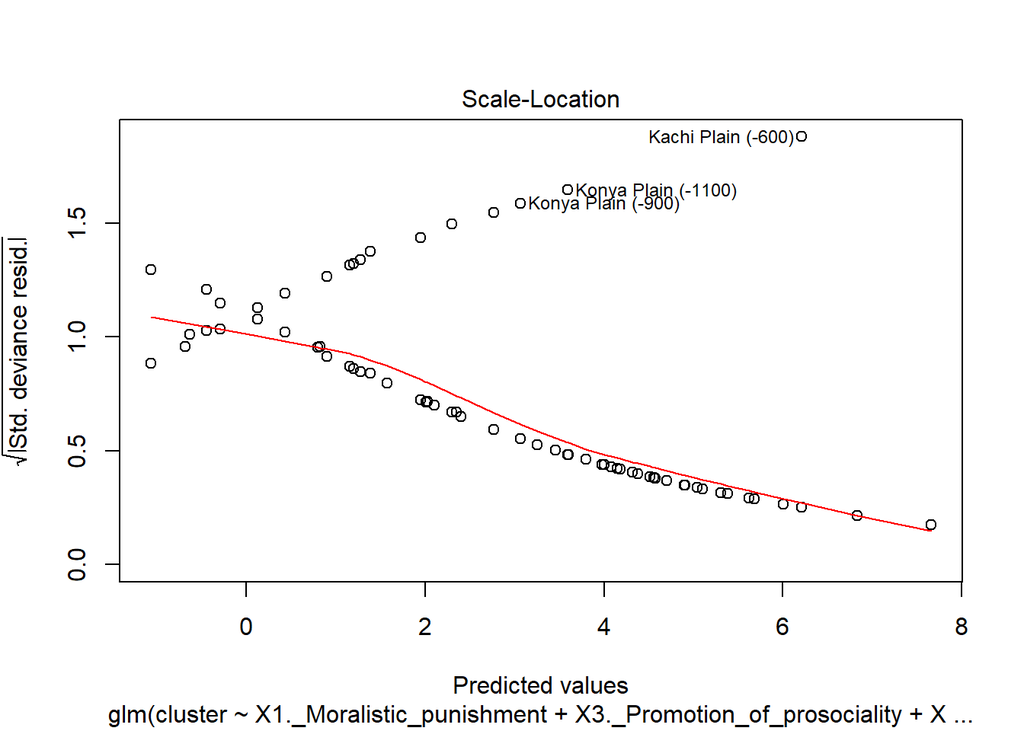

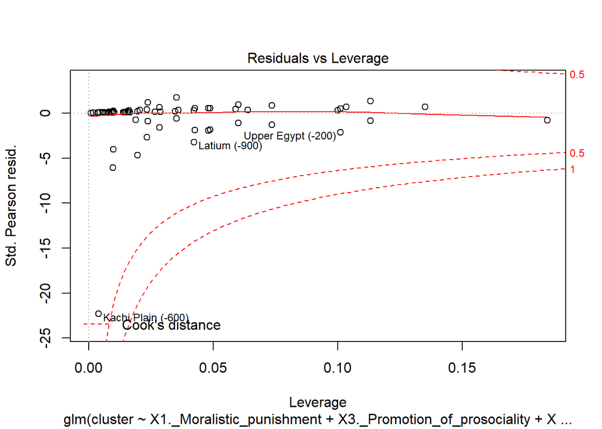

```r
# par(mfrow=c(2,2))
plot(res_AIC)
```